```python
import numpy as np
import pandas as pd
from matplotlib import pyplot as plt
import scipy.stats as st
import math
```

# Problem 4: Inferential Statistics

## Task 1

We start with the verification of the law of large numbers and of the central limit theorem. Thus we check if the mean $\bar{X}$ converges (in probability) to the expectation $\mu$ if the sample size increases and if its distribution converges to the normal distribution.

### Task 1a

Simulate samples of size $n = 10,...,100000$ (with step say 1000) from a normal distribution with mean 1 and variance 1, i.e. $N(1; 1)$. For each sample compute the sample mean and the sample variance. Plot the path of the sample means as a function of $n$. What conclusion can we draw from the figure if we keep in mind the law of large numbers?

```python
mu, sigma = 1, 1
ns = []
means = []
variances = []
np.random.seed(1)
for n in range(10, 100000, 1000):
  sample = np.random.normal(mu, sigma, n)
  ns.append(n)
  sample_mean = np.mean(sample)
  sample_variance = math.sqrt(np.var(sample)) # S
  means.append(sample_mean)
  variances.append(sample_variance)
```

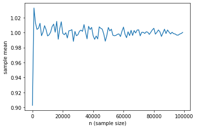

```python
plt.plot(ns, means)
plt.xlabel("n (sample size)")
plt.ylabel("sample mean")
plt.show()
```

With the increasing sample size we can observe the sample mean becomes closer to the true mean.

### Task 1b

Heuristic perspective: how many observations do we need in order to obtain an estimator which is close enough to the true value ($\mu \pm 0.01$)?

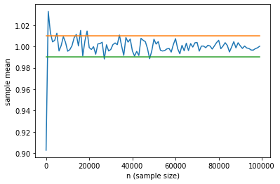

```python
plt.plot(ns, means)
plt.plot([np.min(ns), np.max(ns)], [mu + 0.01, mu + 0.01])
plt.plot([np.min(ns), np.max(ns)], [mu - 0.01, mu - 0.01])
plt.xlabel("n (sample size)")
plt.ylabel("sample mean")
plt.show()
```

Starting from the sample of size $n \sim 50'000$ the sample mean doesn't exceed bounds of $\mu_1(n) = \mu+0.01$ and $\mu_2(n) = \mu-0.01$, and, according to the LLN, it won't.

### Task 1c

For each sample compute manually the 95% confidence interval for the mean and add it to the plot. Do it once with known $\sigma$ and once with an estimated. Discuss what you observe and provide explanation for your findings.

```python
mu, sigma = 1, 1
alpha = 0.95
ns = []
means = []
zCIs_low, zCIs_high = [], []
tCIs_low, tCIs_high = [], []
np.random.seed(1)
for n in range(10, 100000, 1000):
  sample = np.random.normal(mu, sigma, n)

  ns.append(n)
  sample_mean = np.mean(sample)
  sample_variance = math.sqrt(np.var(sample)) # S
  means.append(sample_mean)

  z_low, z_high = st.norm.interval(alpha) # always the same
  z_coeff = sigma / math.sqrt(n)
  zCIs_low.append(sample_mean + z_low * z_coeff)
  zCIs_high.append(sample_mean + z_high * z_coeff)

  t_low, t_high = st.t.interval(alpha = alpha + (1-alpha)/2, df=n-1)
  t_coeff = sample_variance / math.sqrt(n)
  tCIs_low.append(sample_mean - t_high * t_coeff)
  tCIs_high.append(sample_mean + t_high * t_coeff)
```

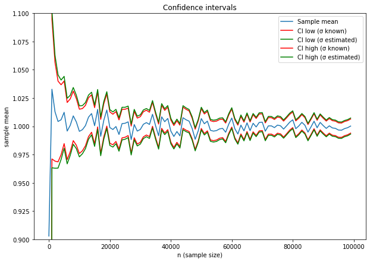

```python
plt.figure(figsize=(10,7))
plt.plot(ns, means, label='Sample mean', color='tab:blue')
plt.plot(ns, zCIs_low, label='CI low (σ known)', color='red')
plt.plot(ns, tCIs_low, label='CI low (σ estimated)', color='green')
plt.plot(ns, zCIs_high, label='CI high (σ known)', color='red')
plt.plot(ns, tCIs_high, label='CI high (σ estimated)', color='green')
plt.ylim((0.9,1.1))
plt.xlabel("n (sample size)")
plt.ylabel("sample mean")
plt.title("Confidence intervals")
plt.legend()
plt.show()
```

1. For small samples: the confidence interval with the known $\sigma$ is slighly smaller, cause we have only a single Random Variable. For the estimated $\sigma$ we need to take more uncertainty to deal with.
2. For relatively big samples: the CIs for known $\sigma$ and estimated almost coincide, cause for large sample sizes sample variance better evaluates the true variance, and t-distributions of many degrees of freedom approach to the normal distribution.

### Task 1d

Simulate $b = 1000$ samples of size $n = 5$ from some weird distribution, for example uniform or $\chi^2$ distribution with $df = 1$. For each sample estimate the mean, the variance and store them. Plot the histogram for the sample of means and the histogram of the sample of variances. Add the densities of the normal distribution for comparison purposes. Compare these densities with the histograms. What do you expect and why (statistical reasoning!)?

```python
means = []
variances = []

b=1000
n=5

for _ in range(b):
  sample = np.random.uniform(size=n)
  sample_mean, sample_variance = np.mean(sample), math.sqrt(np.var(sample))
  means.append(sample_mean)
  variances.append(sample_variance)
```

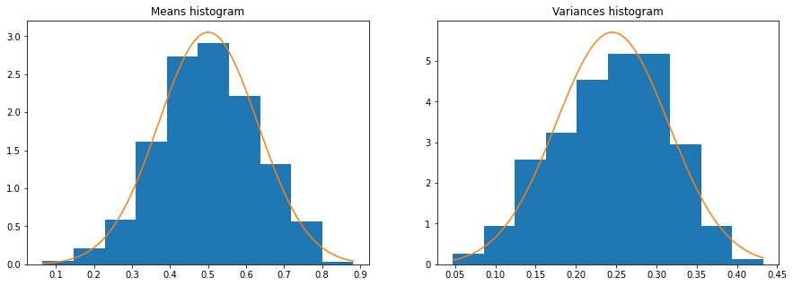

```python
plt.figure(figsize=(15, 5))
plt.subplot(121)
plt.title("Means histogram")
means_x = np.linspace(np.min(means), np.max(means), 100)
means_y = st.norm.pdf(means_x,np.mean(means),math.sqrt(np.var(means)))
plt.hist(means, density=True)
plt.plot(means_x, means_y)
plt.subplot(122)
plt.title("Variances histogram")
variances_x = np.linspace(np.min(variances), np.max(variances), 100)
variances_y = st.norm.pdf(variances_x,np.mean(variances),math.sqrt(np.var(variances)))
plt.hist(variances, density=True)
plt.plot(variances_x, variances_y)
plt.show()
```

We can observe that the histograms have similar shapes as the corresponding normal distributions.

These histograms illustrate the Central Limit Theorem: when independent random variables are added, their properly normalized sum tends toward a normal distribution even if the original variables themselves are not normally distributed

### Task 1e

Let $n$ take values $10^3$, $10^4$, $10^5$ and $10^6$. Check the impact of $n$ on the results. Can the statement of the CLT be confirmed?

```python
means_arr = []
variances_arr = []

b=1000
ns=[1000, 10000, 100000, 1000000]

for n in ns:
  means, variances = [], []
  for _ in range(b):
    sample = np.random.uniform(size=n)
    sample_mean, sample_variance = np.mean(sample), math.sqrt(np.var(sample))
    means.append(sample_mean)
    variances.append(sample_variance)
  means_arr.append(means)
  variances_arr.append(variances)
```

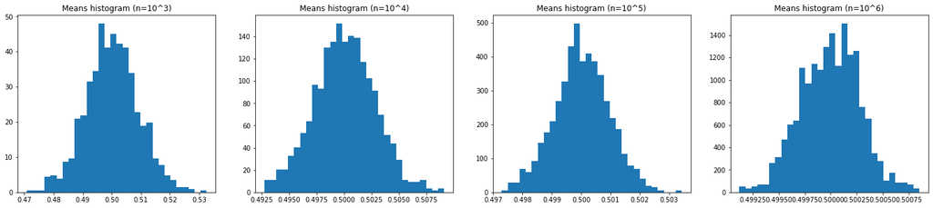

```python
plt.figure(figsize=(25, 5))
plt.subplot(141)
plt.title("Means histogram (n=10^3)")
plt.hist(means_arr[0], density=True, bins=30)
plt.subplot(142)
plt.title("Means histogram (n=10^4)")
plt.hist(means_arr[1], density=True, bins=30)
plt.subplot(143)
plt.title("Means histogram (n=10^5)")
plt.hist(means_arr[2], density=True, bins=30)
plt.subplot(144)
plt.title("Means histogram (n=10^6)")
plt.hist(means_arr[3], density=True, bins=30)
plt.show()
```

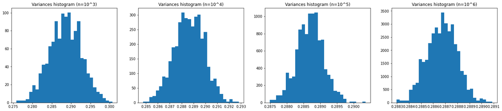

```python
plt.figure(figsize=(25, 5))
plt.subplot(141)
plt.title("Variances histogram (n=10^3)")
plt.hist(variances_arr[0], density=True, bins=30)
plt.subplot(142)
plt.title("Variances histogram (n=10^4)")
plt.hist(variances_arr[1], density=True, bins=30)
plt.subplot(143)
plt.title("Variances histogram (n=10^5)")
plt.hist(variances_arr[2], density=True, bins=30)
plt.subplot(144)
plt.title("Variances histogram (n=10^6)")
plt.hist(variances_arr[3], density=True, bins=30)
plt.show()
```

For all $n$, the resulting histograms approach the normal distrubution, so the CLT statement confirms with that (at least, we cannot reject it). The variance of such histoframs (and the corresponding distributions) drastically differs, however.

### Task 1f

In the lecture we discussed the CLT for the sample mean. Here it seems to apply to the sample variance too. Why?

Let $X_1$, $X_2$, .. $X_n$ - our samples. Its variance (also Random Variable):

$S^2 = \frac{1}{n-1}\sum_{i=1}^{n} (X_i - \bar{X})^2$

This is a sum of distributions, which tends to have a normal distribution due to the CLT.

## Task 2

There is no solution so far.

## Task 3

Here we run a few tests for the data used in the first assignment. For every test write down: the two hypotheses; the formula for the test statistic with inserted values; rejection area computed manually; p-value from your software; your decision and the verbal conclusion (not just sth like $H_0$ is rejected"). Use for all tests $\alpha = 5\%$.

```python
df = pd.read_csv('train.csv')
df.head()
```

|  | Id | MSSubClass | MSZoning | LotFrontage | LotArea | Street | Alley | LotShape | LandContour | Utilities | ... | PoolArea | PoolQC | Fence | MiscFeature | MiscVal | MoSold | YrSold | SaleType | SaleCondition | SalePrice |
| --- | --- | --- | --- | --- | --- | --- | --- | --- | --- | --- | --- | --- | --- | --- | --- | --- | --- | --- | --- | --- | --- |
| 0 | 1 | 60 | RL | 65.0 | 8450 | Pave | NaN | Reg | Lvl | AllPub | ... | 0 | NaN | NaN | NaN | 0 | 2 | 2008 | WD | Normal | 208500 |
| 1 | 2 | 20 | RL | 80.0 | 9600 | Pave | NaN | Reg | Lvl | AllPub | ... | 0 | NaN | NaN | NaN | 0 | 5 | 2007 | WD | Normal | 181500 |
| 2 | 3 | 60 | RL | 68.0 | 11250 | Pave | NaN | IR1 | Lvl | AllPub | ... | 0 | NaN | NaN | NaN | 0 | 9 | 2008 | WD | Normal | 223500 |
| 3 | 4 | 70 | RL | 60.0 | 9550 | Pave | NaN | IR1 | Lvl | AllPub | ... | 0 | NaN | NaN | NaN | 0 | 2 | 2006 | WD | Abnorml | 140000 |
| 4 | 5 | 60 | RL | 84.0 | 14260 | Pave | NaN | IR1 | Lvl | AllPub | ... | 0 | NaN | NaN | NaN | 0 | 12 | 2008 | WD | Normal | 250000 |

5 rows × 81 columns

```python
alpha = 0.05
```

### Task 3a

The real estate company argues that the mean sale price is larger than $180000$. Can this be confirmed with an appropriate test?

```python
sale_prices = df['SalePrice']
```

$\mu_0 = 180000$

$H_0$: $\mu \le \mu_0$

$H_1$: $\mu > \mu_0$

Test statistic ($\sigma$ is unknown):

$V = \sqrt{n}\frac{\bar{X}-\mu_0}{s} \sim t_{n-1}$

```python
mu0 = 180000
v = math.sqrt(len(sale_prices)) * (sale_prices.mean()-mu0) / math.sqrt(sale_prices.var())
print("v =", v)
```

```
v = 0.44307321990459303
```

Rejection area:

$B = (t_{n-1;1-\alpha}; +\infty)$

```python
t_low, t_high = st.t.interval(alpha=1-2*alpha, df=len(sale_prices) - 1) # (1-2*alpha) for the 2-sided test gives (1-alpha) for the right-sided test
print("B = ({}; +inf)".format(t_high))
```

```
B = (1.6458986872790866; +inf)
```

```python
v_calc, p_calc = st.ttest_1samp(sale_prices, mu0) # we cannot do one-sided tests with scipy :(
print("t-statistic:", v_calc)
print("p-value:", p_calc)
```

```
t-statistic: 0.44307321990459303
p-value: 0.6577784607522807
```

$v \notin B$, so we cannot reject $H_0$. In other words, we cannot confirm that the mean sale price is larger than 180000.

### Task 3b

We would like to check if the sale price of two-story houses is significantly different than the sale price of one-story houses (HouseType). Assume that the variances are unknown and not necessarily equal.

```python
two_story_prices = df[df['HouseStyle'] == '2Story']['SalePrice']
one_story_prices = df[df['HouseStyle'] == '1Story']['SalePrice']

print("2 story count:", len(two_story_prices))
print("1 story count:", len(one_story_prices))
```

```
2 story count: 445
1 story count: 726
```

$H_0$: $\mu_1 = \mu_2$

$H_1$: $\mu_1 \ne \mu_2$

Test statistic:

$V = \frac{\bar{X} - \bar{Y}}{\sqrt{\frac{\sigma_1^2}{n_1}+\frac{\sigma_2^2}{n_2}}}$

```python
v = (two_story_prices.mean()-one_story_prices.mean()) / math.sqrt(two_story_prices.var()/len(two_story_prices) + one_story_prices.var()/len(one_story_prices))
print("v =", v)
```

```
v = 6.770016704251018
```

Rejection area

$B = (-\infty; -z_{1-\alpha/2}) \cup (z_{1-\alpha/2}; +\infty)$

```python
z_low, z_high = st.norm.interval(1-alpha)
print("B = (-inf; {}) union ({}; +inf)".format(z_low, z_high))
```

```
B = (-inf; -1.959963984540054) union (1.959963984540054; +inf)
```

```python
v_calc, p_calc = st.ttest_ind(two_story_prices, one_story_prices, equal_var=False)
print("t-statistic:", v_calc)
print("p-value:", p_calc)
```

```
t-statistic: 6.770016704251018
p-value: 2.3993364702401085e-11
```

Note: *ttest_ind* rejection area constructs from the t-distrubution, but for large n it is a pretty good approximation of the normal distribution (we don't have two-sample Z-tests in scipy).

$v \in B$, so we reject $H_0$. In other words, the sale price of two-story houses is significantly different than the sale price of one-story houses ($H_1$ confirmed).

### Task 3c

We suspect that the sale price is not related to the year of construction (YearBuilt). Check this using the Pearson correlation coefficient.

```python
sale_prices = df['SalePrice']
year_builts = df['YearBuilt']

print(len(sale_prices), len(year_builts))
```

```
1460 1460
```

We are going to test against $\rho$ (the Pearson correlation coefficient):

$H_0$: $\rho = 0$ ($X$ and $Y$ are uncorrelated)

$H_1$: $\rho \ne 0$

Test statistics:

$v = \sqrt{n-2}\frac{\hat{\rho}}{\sqrt{1-\hat{\rho}^2}}$

```python
rho_est, p_calc = st.pearsonr(sale_prices, year_builts)
v = math.sqrt(len(sale_prices)-2) * rho_est / math.sqrt(1 - rho_est*rho_est)
print("rho estimated:", rho_est)
print("t-statistic:", v)
print("p-value:", p_calc)
```

```
rho estimated: 0.5228973328794969
t-statistic: 23.42361673746701
p-value: 2.9902290990158995e-103
```

Rejection area

$B = (-\infty; -z_{1-\alpha/2}) \cup (z_{1-\alpha/2}; +\infty)$

```python
z_low, z_high = st.norm.interval(1-alpha)
print("B = (-inf; {}) union ({}; +inf)".format(z_low, z_high))
```

```
B = (-inf; -1.959963984540054) union (1.959963984540054; +inf)
```

### Task 3d

Test if the fraction of one-story houses is significantly higher than the fraction of two-story houses.

```python
one_story_mask = np.array(df['HouseStyle'] == '1Story', dtype=np.int)
two_story_mask = np.array(df['HouseStyle'] == '2Story', dtype=np.int)

print("1 story count:", np.sum(one_story_mask))
print("2 story count:", np.sum(two_story_mask))
```

```
1 story count: 726
2 story count: 445
```

$H_0$: $p_1 \leq p_2$

$H_1$: $p_1 > p_2$

Test statistics

$V = \frac{\bar{X}-\bar{Y}}{\sqrt{\frac{(\sum X_i + \sum Y_i)(n_1 + n_2- \sum X_i - \sum Y_i)}{(n_1+n_2)n_1n_2}}}$

```python
sumX = np.sum(one_story_mask)
sumY = np.sum(two_story_mask)
n1 = len(one_story_mask)
n2 = len(two_story_mask)

v = (np.mean(one_story_mask) - np.mean(two_story_mask)) / math.sqrt(((sumX + sumX) * (n1+n2-sumX-sumY))/((n1+n2)*n1*n2))
print("t-statistic:", v)
```

```
t-statistic: 9.528390176827916
```

Rejection area

$B = (z_{1-\alpha}; +\infty)$

```python
z_low, z_high = st.norm.interval(1-2*alpha) # (1-2*alpha) for the 2-sided test gives (1-alpha) for the right-sided test
print("B = ({}; +inf)".format(z_high))
```

```
B = (1.6448536269514722; +inf)
```

The software I use (scipy) can't compute p-values for two-sample binomail tests :(

$v \in B$, so we reject $H_0$. In other words, the fraction of one-story houses is significantly higher than the fraction of two-story houses ($H_1$ confirmed).

### Task 3e

All the above tests rely on the normality assumption of SalePrice. Check this assumption using the Kolmogorov-Smirnov test. Use only built-it functions, no manual computations here.

```python
sale_prices = df['SalePrice']
```

Test statistic

$D = max_{x \in \mathbb{R}} | \hat{F}(x) - F_0(x) |$

```python
loc = sale_prices.mean()
scale = math.sqrt(sale_prices.var())
d_comp, p_comp = st.kstest(sale_prices, "norm", N=len(sale_prices), args=(loc,scale))
print("t-statistic:", d_comp)
print("p-value:", p_comp)
```

```
t-statistic: 0.12368542719946385
p-value: 6.330230702928437e-20
```

Given so low $p$-value, there is no level of significance (1%, 5%, 10%), at which we can not reject the hypotesis. So, we reject $H_0$. In other words, $SalePrice$ doesn't follow a normal distribution.

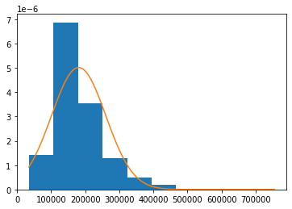

```python
plt.hist(sale_prices, density=True)
x = np.linspace(np.min(sale_prices), np.max(sale_prices), 100)
y = st.norm.pdf(x, loc=loc, scale=scale)
plt.plot(x,y)
plt.show()
```

## Task 4

The next objective is check if the probability of type 1 error (size of a test) is correctly attained by a simple two-sided test for the mean.

### Task 4a

Simulate a sample of length $n = 100$ from a normal distribution with mean $\mu_0 = 500$ and variance $\sigma^2 = 50$. (Note: you may use the transformation $X = \mu + \sigma Z$, where $Z \sim N(0; 1)$.) The objective is to test the null hypothesis $H_0 : \mu = 500$. Assume that $\sigma^2$ has to be estimated. Compute the test statistics using the formulas in the lecture; determine the rejection area for $\alpha = 0.04$ and decide if $H_0$ can be rejected.

```python
alpha = 0.04
n = 100
mu0 = 500
sigma = math.sqrt(50)
sample = st.norm.rvs(loc=mu0, scale=sigma, size=n, random_state=1)
```

Test statistic ($\sigma$ is unknown):

$V = \sqrt{n}\frac{\bar{X}-\mu_0}{s} \sim t_{n-1}$

```python
v = math.sqrt(len(sample)) * (sample.mean()-mu0) / math.sqrt(sample.var())
print("t-statistic:", v)
```

```
t-statistic: 0.6844311899868281
```

Rejection area:

$B = (-\infty; -t_{n-1;1-\alpha/2}) \cup (t_{n-1;1-\alpha/2}; +\infty)$

```python
t_low, t_high = st.t.interval(alpha=1-alpha, df=n - 1)
print("B = (-inf; {}) union ({}; +inf)".format(t_high, t_high))
```

```
B = (-inf; 2.081161540890138) union (2.081161540890138; +inf)
```

$v \notin B$, so we cannot reject $H_0$.

### Task 4b

Simulate $M = 1000$ samples of size $n = 100$ and with $\mu_0 = 500$ and variance $\sigma^2 = 50$. For each sample $i$ run the test (using a standard function) and set $p_i = 0$ if $H_0$ is not rejected and $p_i = 1$ is rejected. Compute $\hat{\alpha} = \frac{1}{M}\sum_{i=1}^{M} p_i$. $\hat{\alpha}$ is the empirical confidence level (empirical size) of the test. Compare $\hat{\alpha}$ with $\alpha$. Do you expect the difference to be large or small and why? Relate it to the assumptions of the test.

```python
P = []
for i in range(10000):
  sample = st.norm.rvs(loc=mu0, scale=sigma, size=n, random_state=i)
  v = math.sqrt(len(sample)) * (sample.mean()-mu0) / math.sqrt(sample.var())
  P.append(int(abs(v) > t_high))
print("Empirical confidence level:", np.mean(P))
```

```
Empirical confidence level: 0.0392
```

$\hat{\alpha}$ coincides with $\alpha$. And it is statistically justified. When we run the test with the rejection area of $\alpha = 0.04$, we are going to fail the test (reject the correct $H_0$) with the probability of $\hat{\alpha} = 0.04$, which describes the type 1 error from the statistical perspective.

## Task 5

**Power of a test**: The next aim is to assess the probability of type 2 error (power of a test) of a goodness-of-fit test. Goodness-of-fit tests for the normal distribution are of key importance in statistics, since they allow to verify the distributional assumptions required in many models. Here we check the power of the Kolmogorov-Smirnov test, i.e. is the test capable to detect deviations from normality?

- Simulate $M = 1000$ samples of size $100$ from a $t$-distribution with $df = 2,...,50$ degrees of freedom. For each sample run the Kolmogorov-Smirnov test and count the cases when the $H_0$ of normality is correctly rejected (for each df). How would you use this quantity to estimate the power of the test? Make an appropriate plot with the df on the X-axis. (Note: the $t$-distribution converges to the normal distribution as df tends to infinity. For $df > 50$ the distributions are almost identical.) Discuss the plot and draw conclusions about the reliability of the test.

```python
n = 100
M = 1000
alpha = 0.05

dfs = np.arange(2, 50)
powers = []

for df in dfs:
  correctly_rejected = 0
  for i in range(M):
    sample = st.t.rvs(df=df, size=n, random_state=df * i)
    statistic, pvalue = st.kstest(sample, "norm", N=n)
    correctly_rejected += int(abs(pvalue) < alpha)
  powers.append(correctly_rejected / M)
```

The probability of cases when the $H_0$ of normality is correctly rejected is $P(\{H_1\}|H_1)$ - *power of a test* by definition.

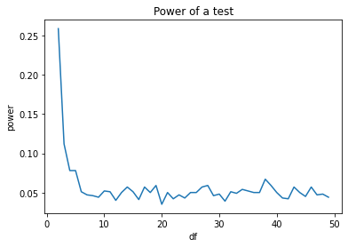

```python
plt.title("Power of a test")
plt.plot(dfs, powers)
plt.xlabel("df")
plt.ylabel("power")
plt.show()
```

Having small $df$, we correctly reject $H_0$ in 10-25% of cases. As $df$ becomes bigger, we correctly reject $H_0$ in 5-10% of cases. This means that our test has a large Type 2 error, which make it "weak" (non-powerful). This means we don't reject normality in many cases where we should.

Summarising, Kolmogorov-Smirnov test doesn't look like a good option for distinguishing $t$-distributions and normal distributions.